# lab_exercise slides

## Assessing Climate Impacts on Maize Yield with a Process-based Model

#### Step 1: Read in simaultion output files

Choose your favorite location to analyze maize yield:

- Nebraska (Neb)
- Ohio (Ohi)
- Iowa (Iow)
- Oklahoma (Okl)

```python
# Load in some useful packages
import pandas as pd
import numpy as np
import matplotlib.pyplot as plt
%matplotlib inline
```

```python
# Read in data files from your location of interest
ohi_control = pd.read_csv('data/Ohi_Control.csv', index_col='date', parse_dates=True)
ohi_temp = pd.read_csv('data/Ohi_Temp.csv', index_col='date', parse_dates=True)
ohi_vpd = pd.read_csv('data/Ohi_VPD.csv', index_col='date', parse_dates=True)
ohi_co2 = pd.read_csv('data/Ohi_CO2.csv', index_col='date', parse_dates=True)
ohi_all = pd.read_csv('data/Ohi_All.csv', index_col='date', parse_dates=True)
```

```python
# Take a look at the data format of the simulation outputs
ohi_control.head()
```

| date | jday | time | Leaves | Dropped | LA/pl | LA_dead | LAI | RH | LeafWP | PFD | ... | GrleafDM | DrpLfDM | stemDM | rootDM | SoilRt | MxRtDep | AvailW | solubleC | Note | Unnamed: 49 |
| --- | --- | --- | --- | --- | --- | --- | --- | --- | --- | --- | --- | --- | --- | --- | --- | --- | --- | --- | --- | --- | --- |
| 2011-05-15 | 40618 | 0 | 0.0 | 0 | 0.0 | 0.0 | 0.0 | 98.7 | -0.05 | 0.0 | ... | 0.17 | 0.0 | 0.02 | 0.0 | 0.176 | 0.0 | 75.459 | 0.0 | none | 14.46 |
| 2011-05-15 | 40618 | 1 | 0.0 | 0 | 0.0 | 0.0 | 0.0 | 100.0 | -0.05 | 0.0 | ... | 0.17 | 0.0 | 0.02 | 0.0 | 0.176 | 195.4 | 75.210 | 0.0 | none | 14.46 |
| 2011-05-15 | 40618 | 2 | 0.0 | 0 | 0.0 | 0.0 | 0.0 | 100.0 | -0.05 | 0.0 | ... | 0.17 | 0.0 | 0.02 | 0.0 | 0.176 | 195.4 | 72.358 | 0.0 | none | 14.46 |
| 2011-05-15 | 40618 | 3 | 0.0 | 0 | 0.0 | 0.0 | 0.0 | 100.0 | -0.05 | 0.0 | ... | 0.17 | 0.0 | 0.02 | 0.0 | 0.176 | 195.4 | 70.891 | 0.0 | none | 14.46 |
| 2011-05-15 | 40618 | 4 | 0.0 | 0 | 0.0 | 0.0 | 0.0 | 100.0 | -0.05 | 0.0 | ... | 0.17 | 0.0 | 0.02 | 0.0 | 0.176 | 195.4 | 69.882 | 0.0 | none | 14.46 |

5 rows × 49 columns

#### Step 2: Plot out some raw model outpus for "Control"

Look at how biomass of different plant parts change throuhout the growing season

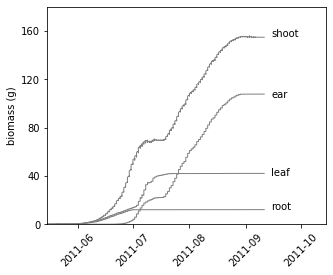

```python
fig, ax = plt.subplots(figsize=(5,4))

ax.plot(ohi_control.rootDM, color='grey', linewidth=1)
ax.plot(ohi_control.shootDM, color='grey', linewidth=1)
ax.plot(ohi_control.GrleafDM, color='grey', linewidth=1)
ax.plot(ohi_control.earDM, color='grey', linewidth=1)
ax.set(xlim=('2011-05-15', '2011-10-15'), ylim=(0,180))
ax.set_ylabel('biomass (g)')
ax.yaxis.set_ticks(np.arange(0,180,40))
ax.tick_params(axis='x', rotation=45)

plt.text('2011-09-15', 12, 'root')
plt.text('2011-09-15', 40, 'leaf')
plt.text('2011-09-15', 105, 'ear')
plt.text('2011-09-15', 155, 'shoot')
```

Look at how several morphological and physiological parameters change throughout the growing season

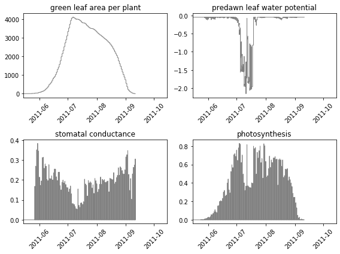

```python
fig, axs = plt.subplots(2,2, figsize=(8,6), tight_layout=True)

axs[0,0].plot(ohi_control['LA/pl'], color='grey', linewidth=1)
axs[0,0].set(xlim=('2011-05-15', '2011-10-15'))
axs[0,0].tick_params(axis='x', rotation=45)
axs[0,0].title.set_text('green leaf area per plant')

axs[0,1].plot(ohi_control.LeafWP, color='grey', linewidth=1)
axs[0,1].set(xlim=('2011-05-15', '2011-10-15'))
axs[0,1].tick_params(axis='x', rotation=45)
axs[0,1].title.set_text('predawn leaf water potential')

axs[1,0].plot(ohi_control.av_gs, color='grey', linewidth=1)
axs[1,0].set(xlim=('2011-05-15', '2011-10-15'))
axs[1,0].tick_params(axis='x', rotation=45)
axs[1,0].title.set_text('stomatal conductance')

axs[1,1].plot(ohi_control.Pn, color='grey', linewidth=1)
axs[1,1].set(xlim=('2011-05-15', '2011-10-15'))
axs[1,1].tick_params(axis='x', rotation=45)
axs[1,1].title.set_text('photosynthesis')
```

#### Step 3: Compare raw data from different treatment

- Control (grey): model simulations ran with weather station data input
- Temp (orange): 2˚C warming without drying the air (no change in VPD)
- VPD (purple): drying of air associated with 2˚C warming, but with temperature held constant
- CO2 (green): doubling CO2 levels from 400 ppm to 800 ppm

```python
# setting colorschemes
col_control = 'grey'
col_temp = 'sandybrown'
col_vpd = 'slateblue'
col_co2 = 'mediumseagreen'
```

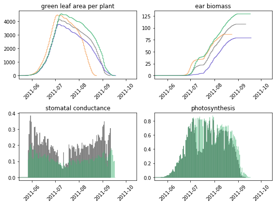

```python
fig, axs = plt.subplots(2,2, figsize=(8,6), tight_layout=True)

axs[0,0].plot(ohi_control['LA/pl'], color=col_control, linewidth=1)
axs[0,0].plot(ohi_temp['LA/pl'], color=col_temp, linewidth=1)
axs[0,0].plot(ohi_vpd['LA/pl'], color=col_vpd, linewidth=1)
axs[0,0].plot(ohi_co2['LA/pl'], color=col_co2, linewidth=1)
axs[0,0].set(xlim=('2011-05-15', '2011-10-15'))
axs[0,0].tick_params(axis='x', rotation=45)
axs[0,0].title.set_text('green leaf area per plant')

axs[0,1].plot(ohi_control.earDM, color=col_control, linewidth=1)
axs[0,1].plot(ohi_temp.earDM, color=col_temp, linewidth=1)
axs[0,1].plot(ohi_vpd.earDM, color=col_vpd, linewidth=1)
axs[0,1].plot(ohi_co2.earDM, color=col_co2, linewidth=1)
axs[0,1].set(xlim=('2011-05-15', '2011-10-15'))
axs[0,1].tick_params(axis='x', rotation=45)
axs[0,1].title.set_text('ear biomass')

axs[1,0].plot(ohi_control.av_gs, color=col_control, linewidth=1)
axs[1,0].plot(ohi_co2.av_gs, color=col_co2, alpha=0.5, linewidth=1)
axs[1,0].set(xlim=('2011-05-15', '2011-10-15'))
axs[1,0].tick_params(axis='x', rotation=45)
axs[1,0].title.set_text('stomatal conductance')

axs[1,1].plot(ohi_control.Pn, color=col_control, linewidth=1)
axs[1,1].plot(ohi_co2.Pn, color=col_co2, alpha=0.5, linewidth=1)
axs[1,1].set(xlim=('2011-05-15', '2011-10-15'))
axs[1,1].tick_params(axis='x', rotation=45)
axs[1,1].title.set_text('photosynthesis')
```

#### Step 4: Take a finer look at the model outputs

There are several ways you can further process the model outputs.  
For some outputs, further process is necessary since the hourly model output can be very noisy.  
Averaging is a simple way to make sense of these kind of outptus. Here are a couple options:

- Take a daily mean
- Take a monthly mean
- Take the mean across the whole growing season
- Average over a specific phenological stage.

```
- Emerged
- Tasselinit (tassel initiaiton)
- Silked
- Grainfill (grain filling)
- Maturation
```

Summing values over a period of time (daily, monthly, growing season, developmental stage) is also a good option for certain outputs. Sometime, looking at a certain time in the day can be useful as well. For example, analyzing leaf water potential outptus at 5am as a rough estimate of "predawn leaf water potential"

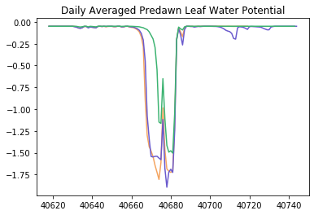

```python
# Daily averages
plt.plot(ohi_temp.groupby('jday').mean().LeafWP, color=col_temp)
plt.plot(ohi_vpd.groupby('jday').mean().LeafWP, color=col_vpd)
plt.plot(ohi_co2.groupby('jday').mean().LeafWP, color=col_co2)
plt.title('Daily Averaged Predawn Leaf Water Potential')
```

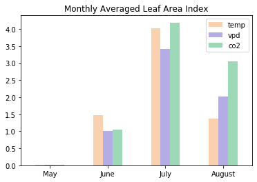

```python
# Monthly averages
monthly_lai_temp = list(ohi_temp.groupby(ohi_temp.index.month).mean().LAI)
monthly_lai_vpd = list(ohi_vpd.groupby(ohi_vpd.index.month).mean().LAI)[0:4]
monthly_lai_co2 = list(ohi_co2.groupby(ohi_co2.index.month).mean().LAI)[0:4]
index = ['May', 'June', 'July', 'August']

df = pd.DataFrame({'temp': monthly_lai_temp,
                   'vpd': monthly_lai_vpd,
                   'co2': monthly_lai_co2}, index=index)

df.plot.bar(rot=0, color=[col_temp, col_vpd, col_co2], alpha=0.5)
plt.title('Monthly Averaged Leaf Area Index')
```

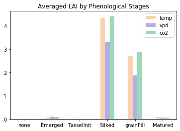

```python
# Averages for each phenological stage
phenostages = ['none', 'Emerged', 'TasselInit', 'Silked', 'grainFill', 'Matured']

pheno_lai_temp = ohi_temp.groupby('Note', sort=False).mean().LAI
pheno_lai_vpd = ohi_vpd.groupby('Note', sort=False).mean().LAI
pheno_lai_co2 = ohi_co2.groupby('Note', sort=False).mean().LAI

df = pd.DataFrame({'temp': pheno_lai_temp,
                   'vpd': pheno_lai_vpd,
                   'co2': pheno_lai_co2}, index=phenostages)

df.plot.bar(rot=0, color=[col_temp, col_vpd, col_co2], alpha=0.5)
plt.title('Averaged LAI by Phenological Stages')
```

#### Bonus: Further exploration

There are so many ways you can explore these model outputs.  
Linking related model outputs together, comparing values throuhout different developmental stages,  
comparing between simulation sites, looking into interaction terms etc. Get creative, and have fun with the data!